# case_8.1

```python
        elif income == 4:
            if corner:
                dessert_probs = [0.4, 0.6, 0.8,1]
                weekday_probs = [0.5, 1]
                lunch_probs = [0.5, 1]
                meat_probs = [0.45, 0.8, 0.9, 1]
                cheese_probs = [0.33, 0.66, 0.99, 1]
                bread_probs = [0.15, 0.3, 0.45, 1]
            else:
                dessert_probs = [0.1, 0.5, 0.75, 1]
                weekday_probs = [0.5, 1]
                lunch_probs = [0.5, 1]
                meat_probs = [0.35, 0.7, 0.9, 1]
                cheese_probs = [0.3, 0.6, 0.9, 1]
                bread_probs = [0.15, 0.3, 0.45, 1]
    elif kids == 4:
        seed_lunch = -np.exp(-0.25 * seed_lunch) + 1
        if income == 1:
            if corner:
                dessert_probs = [0.4, 0.6, 0.8,1]
                weekday_probs = [0.5, 1]
                lunch_probs = [0.5, 1]
                meat_probs = [0.3, 0.6, 0.8, 1]
                cheese_probs = [0.25, 0.5, 0.75, 1]
                bread_probs = [0.3, 0.6, 0.9, 1]
            else:
                dessert_probs = [0.1, 0.5, 0.75, 1]
                weekday_probs = [0.5, 1]
                lunch_probs = [0.5, 1]
                meat_probs = [0.2, 0.4, 0.7, 1]
                cheese_probs = [0.23, 0.46, 0.69, 1]
                bread_probs = [0.3, 0.6, 0.9, 1]
        elif income == 2:
            if corner:
                dessert_probs = [0.4, 0.6, 0.8,1]
                weekday_probs = [0.5, 1]
                lunch_probs = [0.5, 1]
                meat_probs = [0.3, 0.6, 0.8, 1]
                cheese_probs = [0.26, 0.52, 0.78, 1]
                bread_probs = [0.25, 0.5, 0.75, 1]
            else:
                dessert_probs = [0.1, 0.5, 0.75, 1]
                weekday_probs = [0.5, 1]
                lunch_probs = [0.5, 1]
                meat_probs = [0.25, 0.5, 0.75, 1]
                cheese_probs = [0.25, 0.5, 0.75, 1]
                bread_probs = [0.25, 0.5, 0.75, 1]
        elif income == 3:
            if corner:
                dessert_probs = [0.4, 0.6, 0.8,1]
                weekday_probs = [0.5, 1]
                lunch_probs = [0.5, 1]
                meat_probs = [0.4, 0.7, 0.85, 1]
                cheese_probs = [0.3, 0.6, 0.9, 1]
                bread_probs = [0.2, 0.4, 0.6, 1]
            else:
                dessert_probs = [0.1, 0.5, 0.75, 1]
                weekday_probs = [0.5, 1]
                lunch_probs = [0.5, 1]
                meat_probs = [0.3, 0.6, 0.8, 1]
                cheese_probs = [0.26, 0.52, 0.78, 1]
                bread_probs = [0.2, 0.4, 0.6, 1]
        elif income == 4:
            if corner:
                dessert_probs = [0.4, 0.6, 0.8,1]
                weekday_probs = [0.5, 1]
                lunch_probs = [0.5, 1]
                meat_probs = [0.45, 0.8, 0.9, 1]
                cheese_probs = [0.33, 0.66, 0.99, 1]
                bread_probs = [0.15, 0.3, 0.45, 1]
            else:
                dessert_probs = [0.1, 0.5, 0.75, 1]
                weekday_probs = [0.5, 1]
                lunch_probs = [0.5, 1]
                meat_probs = [0.35, 0.7, 0.9, 1]
                cheese_probs = [0.3, 0.6, 0.9, 1]
                bread_probs = [0.15, 0.3, 0.45, 1]

    return responses(dessert_probs, weekday_probs, lunch_probs, meat_probs, cheese_probs, bread_probs)
```

```python
get_answers(0)
```

```
['tres leches',
 'weekend',
 'dinner',
 'roasted veggies',
 'doble crema',
 'artisinal']
```

```python
df.head()
```

|  | building | kids | crosses_corner | income_quartile | desserts | weekday/weekend | lunch/dinner | meat | cheese | bread |
| --- | --- | --- | --- | --- | --- | --- | --- | --- | --- | --- |
| 0 | 1 | 0 | False | 4 | NaN | NaN | NaN | NaN | NaN | NaN |
| 1 | 1 | 2 | False | 4 | NaN | NaN | NaN | NaN | NaN | NaN |
| 2 | 1 | 2 | False | 4 | NaN | NaN | NaN | NaN | NaN | NaN |
| 3 | 1 | 2 | False | 4 | NaN | NaN | NaN | NaN | NaN | NaN |
| 4 | 1 | 4 | True | 2 | NaN | NaN | NaN | NaN | NaN | NaN |

This code creates data.csv which is used for a dataframe later. This takes a long time to run so this code is provided for your reference but you should use the data.csv file already provided in this case.

```
for i in df.index:
    responses = get_answers(i)
    for j, col in enumerate(['desserts', 'weekday/weekend', 'lunch/dinner', 'meat', 'cheese', 'bread']):
        df.loc[i, col] = responses[j]

df.to_csv('data.csv')
```

## Target populations (15 min)

We are interested in learning about attributes from individuals of a population. In our case, the attributes we are interested in are the preferences that will help us to design a good menu for our sandwich shop.

The population we intend to study is called the **target population**. In our case the population we would like to study is the set of potential customers, which is the set of all (~100,000) people working in the buildings surrounding our new shop:

```python
df = pd.read_csv('data.csv', index_col=0)
df.head()
```

|  | building | kids | crosses_corner | income_quartile | desserts | weekday/weekend | lunch/dinner | meat | cheese | bread |
| --- | --- | --- | --- | --- | --- | --- | --- | --- | --- | --- |
| 0 | 1 | 1 | True | 3 | oblea | weekday | dinner | chicken | provolone | artisinal |
| 1 | 1 | 1 | False | 1 | arequipe | weekend | lunch | steak | provolone | white |
| 2 | 1 | 3 | False | 1 | tres leches | weekday | lunch | steak | doble crema | wheat |
| 3 | 1 | 4 | True | 2 | oblea | weekday | lunch | ham | Swiss | artisinal |
| 4 | 1 | 2 | False | 4 | arequipe | weekday | lunch | chicken | provolone | wheat |

The above dataset contains the true preferences of all the 100,000 customers in our target population. For the sake of this problem, we'll sample from this dataset. However, in a real-life sampling context, we can't view this entire dataset, and we must attempt to draw conclusions based on imperfect and/or incomplete samples. Keep this in mind as we go through this case – we will make note of when this restriction is likely to affect real-life workflows vs. our workflow here, as well as how to generally deal with it.

### Convenience sampling (10 min)

One naive way to collect a sample would be to pick a fixed location on the corner of our shop and give the questionnaire to the first 100 people willing to take it. This is called a **convenience sample**.

### Exercise 2: (5 min)

What are some problems with a convenience sample?

**Answer.** There are many, but two of them are:

1. Bias in our results. The people who are convenient for us to sample may not be representative of the target population as a whole. For example, there may be a bias towards time of day, as well as location because we are only picking one corner of the shop, which only certain segments of our potential customer base may enter through on a daily basis.
2. Competition for the same customer segment. If the set of people who are easily willing to take your survey is convenient for you to sample, it's likely also convenient for other restaurants. So you may end up competing more brutally for a small section of the market, cutting into profits.

Let's sample from the population based on whether or not a potential customer crosses the corner at which we are sampling from:

```python
survey_answers = ['desserts', 'weekday/weekend', 'lunch/dinner', 'meat', 'cheese', 'bread']
```

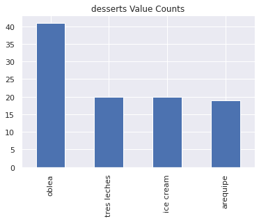

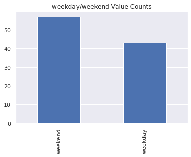

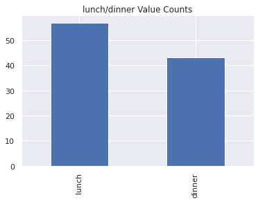

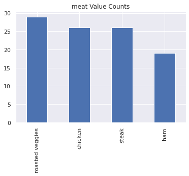

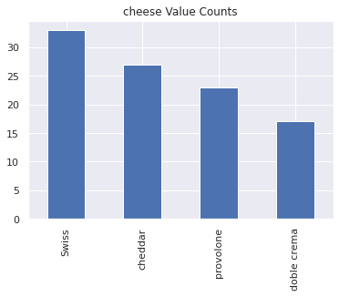

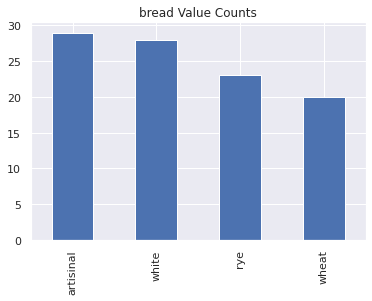

```python
mask = r.choice(df.loc[df['crosses_corner'] == True].index, 100)
conv_sample = df.loc[mask]

for col in survey_answers:
    fig, ax = plt.subplots()
    ax.set_title(col + ' Value Counts')
    conv_sample[col].value_counts().plot(kind='bar')
    plt.show()
```

Of course, the results above exhibit randomness, and will not stay the same each time we run the same block of code. This is because we will be sampling a different 100 people every time.

Let's see how well the histograms above match the true values in our full population dataset. Of course, note that in a real-life setting, we would not have the luxury of being able to compare our samples to the full population – this is just for instructional purposes:

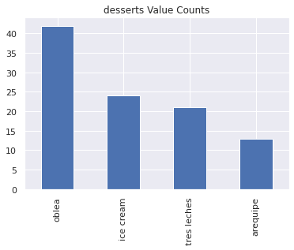

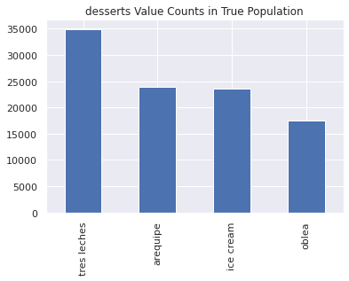

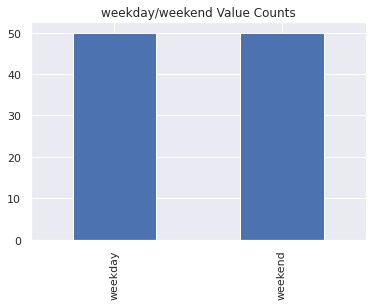

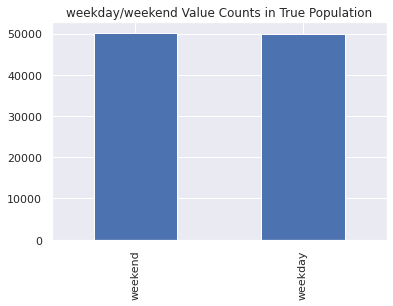

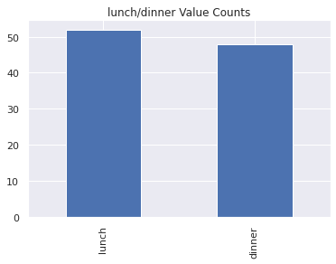

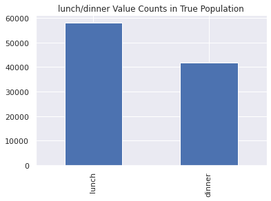

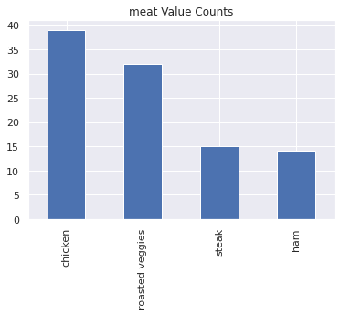

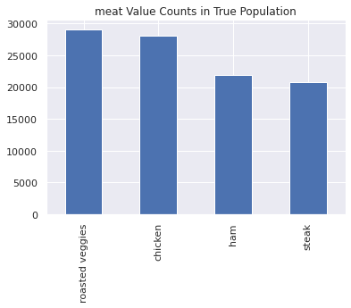

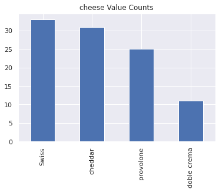

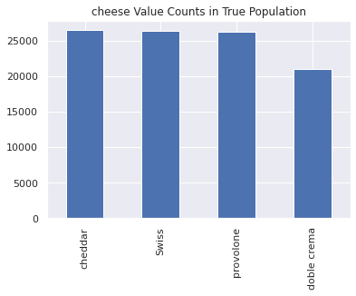

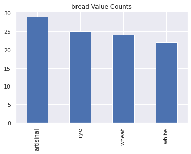

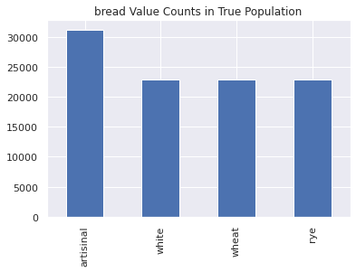

```python
mask = r.choice(df.loc[df['crosses_corner'] == True].index, 100)
conv_sample = df.loc[mask]

for col in survey_answers:
    fig, ax = plt.subplots()
    ax.set_title(col + ' Value Counts')
    conv_sample[col].value_counts().plot(kind='bar')
    plt.show()
    fig, ax = plt.subplots()
    ax.set_title(col + ' Value Counts in True Population')
    df[col].value_counts().plot(kind='bar')
    plt.show()
```

Once again, we should be very disheartened to see these results. It seems like our convenience sampling isn't representative of our population as a whole along most metrics. This motivates us to look at other sampling methods.

## Simple random sampling (25 min)

Rather than sampling based on our convenience, we can be a little more scientific by randomly selecting potential customers from the entirety of our target population. The approach here is as follows:

1. Obtain 100 elements from {1, 2, ..., 100000} using a random number generator
2. Apply the questionnaire to the members of the population associated with the numbers we obtained in step 1

The procedure just described can be applied for any population with $N$ elements and a desired sample size $n$, with $n < N$. This is known as **simple random sampling**.

### Exercise 3: (10 min)

Create bar charts to view the survey results under a simple random sample of the dataset. Also, plot a bar chart that shows the variability of the top answer for `cheese` over 200 simple random samples.

**Answer.** One possible solution is shown below:

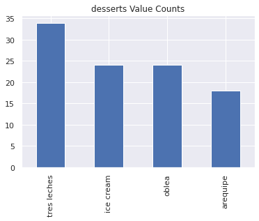

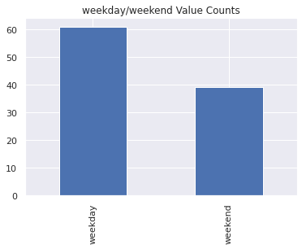

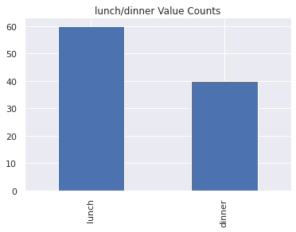

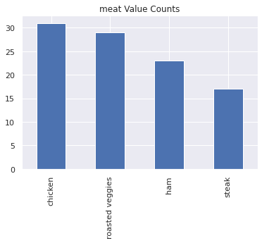

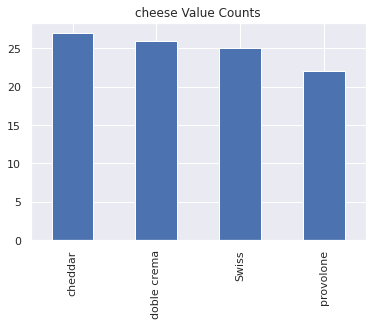

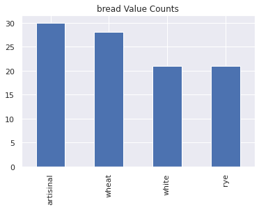

```python
mask = r.choice(df.index, 100)
srs_sample = df.loc[mask]

for col in survey_answers:
    fig, ax = plt.subplots()
    ax.set_title(col + ' Value Counts')
    srs_sample[col].value_counts().plot(kind='bar')
    plt.show()
```

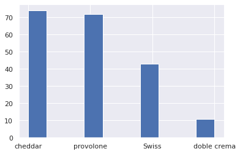

```python
most_popular_cheese = []
for _ in range(200):
    mask = r.choice(df.index, 100)
    srs_sample = df.loc[mask]['cheese']
    most_popular_cheese.append(srs_sample.value_counts().idxmax())
plt.hist(most_popular_cheese)
```

This illustrates a prime problem with simple random sampling. In theory, our sample is supposed to be representative of the population. However, because our samples are so small, the variance between samples is significant.

### Exercise 4: (5 min)

Create a bar chart that shows the variability in the top `cheese` choice in 200 simple random samples when each sample is of size 50000 rather than 100.

**Answer.** One possible solution is shown below:

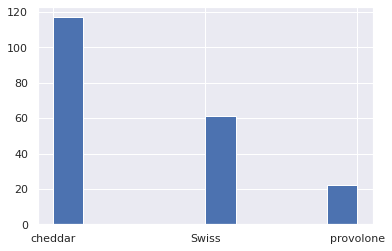

```python
most_popular_cheese = []
for _ in range(200):
    mask = r.choice(df.index, 50000)
    srs_sample = df.loc[mask]['cheese']
    most_popular_cheese.append(srs_sample.value_counts().idxmax())
plt.hist(most_popular_cheese)
```

This shows how we can reduce variability by increasing the sample size. But in the real world, we'll run against cost and time constraints (in the extreme, this approach reduces to sampling every single person in the target population). We will now consider methods that guarantee representativeness of the population while being far less prohibitive than simple random sampling in terms of sample size.

### Heterogeneity (5 min)

Summaries like the estimate of the proportion of people that often go for the vegetarian option tend to assume that the data is generated by a simple model. This implies that breaking down the population into categories, like income bracket, should create sub-populations with the same behavior as the entire population.

Of course, this is often not the case: it may well be the case that project managers, because of their higher income, regularly go for healthier options with pricier ingredients when compared to workers with noticeably lower income. If splitting the population along a certain feature produces sub-populations with notably different behaviors, then we say that the population is **heterogeneous**.

Heterogeneity is detrimental for the performance of the statistics obtained under simple random sampling. But we can make heterogeneity our friend with a divide-and-conquer strategy: we can group the population by income bracket, and perform simple random sampling on each group!

## Stratified sampling (25 min)

**Stratified sampling** is a strategy designed to take into account the heterogeneity of the population. By doing this, we obtain procedures with smaller standard error. There are three steps to forming a stratified sample:

1. Choose which feature we want to use to form subgroups in and sample from.
2. Random sample a proportional amount from each subgroup. For example, if 20% of our population has 2 children, we should choose 20% of our sample number from this subgroup.
3. Put together these samples to form a stratified sample of the entire dataset.

### Exercise 5: (5 min)

For the columns `building`, `kids`, and `income_quartile` in `df`, find the proportion of the population in each category within these features. (Note that in practice, this may not be easy to compute, but for our sake we can calculate the proportion precisely.)

**Answer.** One possible answer is shown below:

```python
### Suggested answer
for col in ['building', 'kids', 'income_quartile']:
    print(df[col].value_counts().sort_index() / len(df))

building_proportions = df['building'].value_counts() / len(df)
kids_proportions = df['kids'].value_counts() / len(df)
income_proportions = df['income_quartile'].value_counts() / len(df)
```

```
1    0.25
2    0.25
3    0.25
4    0.25
Name: building, dtype: float64
0    0.14939
1    0.24816
2    0.45402
3    0.09904
4    0.04939
Name: kids, dtype: float64
1    0.22542
2    0.31222
3    0.27498
4    0.18738
Name: income_quartile, dtype: float64
```

### Exercise 6: (15 min)

For each of the above features, take a stratified sample of `df` along the categories of said feature. (Please stratify along each feature one at a time, rather than all three at once; this means that you will be taking three separate samples.) Plot the bar chart of dessert preferences under each stratification, as well as the variability of most favored dessert over 200 iterations under each stratification.

**Answer.** One possible solution is shown below:

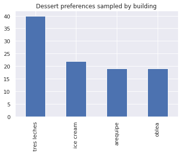

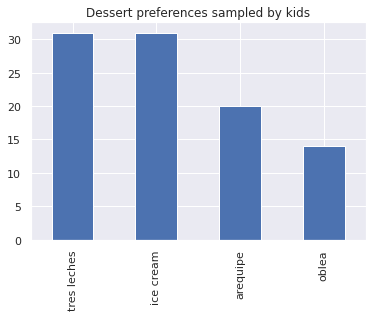

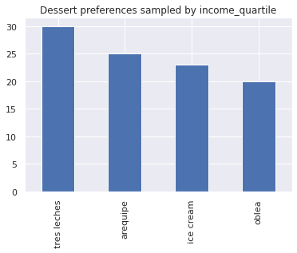

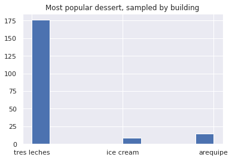

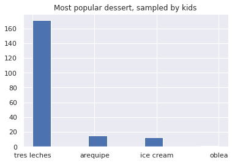

[figure not shown]

```python
building_mask = np.concatenate([r.choice(df.loc[df['building'] == i].index, int(building_proportions[i] * 100))
                                for i in building_proportions.index])

kids_mask = np.concatenate([r.choice(df.loc[df['kids'] == i].index, int(kids_proportions[i] * 100))
                            for i in kids_proportions.index])

income_mask = np.concatenate([r.choice(df.loc[df['income_quartile'] == i].index, int(income_proportions[i] * 100))
                              for i in income_proportions.index])
mask = {'building': building_mask, 'kids': kids_mask, 'income_quartile': income_mask}

for col in ['building', 'kids', 'income_quartile']:
    strat_sample = df.loc[mask[col]]['desserts']
    fig, ax = plt.subplots()
    ax.set_title('Dessert preferences sampled by '+ col)
    strat_sample.value_counts().plot(kind='bar')
    plt.show()

most_popular_by_building = []
for _ in range(200): # By building
    mask = np.concatenate([r.choice(df.loc[df['building'] == i].index, int(building_proportions[i] * 100))
                           for i in building_proportions.index])
    strat_sample = df.loc[mask]['desserts']
    most_popular_by_building.append(strat_sample.value_counts().idxmax())

fig, ax = plt.subplots()
ax.set_title('Most popular dessert, sampled by building')
plt.hist(most_popular_by_building)

most_popular_by_kids = []
for _ in range(200): # By kids
    mask = np.concatenate([r.choice(df.loc[df['kids'] == i].index, int(kids_proportions[i] * 100))
                           for i in kids_proportions.index])
    strat_sample = df.loc[mask]['desserts']
    most_popular_by_kids.append(strat_sample.value_counts().idxmax())

fig, ax = plt.subplots()
ax.set_title('Most popular dessert, sampled by kids')
plt.hist(most_popular_by_kids)

most_popular_by_income = []
for _ in range(200): # By kids
    mask = np.concatenate([r.choice(df.loc[df['income_quartile'] == i].index, int(income_proportions[i] * 100))
                           for i in income_proportions.index])
    strat_sample = df.loc[mask]['desserts']
    most_popular_by_income.append(strat_sample.value_counts().idxmax())

fig, ax = plt.subplots()
ax.set_title('Most popular dessert, sampled by income')
plt.hist(most_popular_by_income)
```

These seem like excellent results! We can see there is low variability within each sample, and the samples all tend to agree with each other. In many practical settings, proper construction of a stratified sample is often sufficient. However, as we have discussed, effective stratified sampling requires us to have good approximations of the category split of the population across different features. In some cases, this is not possible, so we will turn to another sampling method that can deal with such unknowns better.